# module3_project_pombo

**Module 3: Project**

Juanita Pombo

02/25/2025

*Library imports*

```python
import requests
from bs4 import BeautifulSoup
import numpy as np
import time
from sklearn.gaussian_process import GaussianProcessRegressor
from scipy.stats import norm
from sklearn.decomposition import PCA
import matplotlib.pyplot as plt
```

**Project overview:**

In this project, I use Bayesian Optimization to independently optimize two material responses of a tire nanocomposite.

The approach follows an iterative process where we initialize and continuously train a Gaussian Process (GP) based on the results of Finite Element Analysis (FEA) simulations of the initial and selected parameters. Initially, five points are randomly generated within the allowable parameter bounds, and the corresponding material responses, y, are obtained from these FEA simulations.

Notably, the batch size in this workflow is set to 5, meaning that the five best perfoming candidates on the acquisition function (EI) points are selected per batch, and optimization proceeds over 10 batches. I run FEA simulations on all best perfoming candidates selected, resulting in a total of 5x10 FEA simulations. This is in addition to the 5 initial simulations required to initialize the GP model.

Throughout the optimization, the results from the current batch of 5 simulations are concatenated with the data from previous batches. We track the best cumulative response over all batches to monitor the optimization progress. To visualize the evolution of the optimization process, I plot the best cumulative response as a function of the batch number (from 1 to 10). Additionally, to better understand how the input space is explored and exploited using the EI function, the selected data points from each batch are projected into the first two principal components and visualized in 2D. This helps illustrate the distribution and progression of the selected input data over the course of the optimization.

Here, I explore independently maximizing the Sound Damping response and minimizing the Material Cost response.

**Description of Functions**

To make the code portable, most functionalities are abstracted into functions. The functions used in this code are:

- **submit_jobs**: Submits a batch of jobs to the webserver by filling out a form with parameters (params). It returns a list of URLs where the results can be retrieved from.
- **job_submission_loop**: Loops through an array with the simulation parameters for running a number of simulations subsequently. It calls submit_jobs for each row of the input parameter, and stores the result URLs.
- **get_results**: Polls the result pages for each job until the desired output is found or a timeout is reached. It retrieves the specific optimization output from the results table.
- **create_candidate_points**: Generates random integers as candidate points within specified parameter bounds (param_mins and param_maxs).
- **expected_improvement**: Computes the Expected Improvement (EI) for each candidate point based on the Gaussian Process model, helping select the next set of parameters to optimize. This is the chosen acquisition function, and has the capability of computing the function for maximization and minimization based on the user's defined need.
- **optimization_step**: Chooses the next batch of candidate points to evaluate, based on the expected improvement of the Gaussian Process model, and returns the next points to test. The next points are chosen as the top or bottom 'batchsize' (int) perfoming points on the acquisition function for maximization or minimization, respectively.
- **plot_evolutions**: Plots two plots side by side. On the left the evolution of the best observed value (y_best) over optimization batches. On the right the selected candidate points based on the acquisition function projected onto the space formed by the first two principal components of the data.
- **GP_initialization**: Initializes the Gaussian Process model by submitting initial jobs calling job_submission_loop, retrieving the results calling get_results, and fitting the GP model to the initial training data.
- **GP_workflow**: Implements the full GP-based optimization process, where in each iteration (batch):
  1. new candidate points are explored
  2. new candidates points are evaluated on the acquisition function
  3. a number (set by batch_size) of best performing candidate points are selected based on the acquisition function evaluation
  4. jobs are submitted for the selected best perfoming points from the server
  5. the job results are fetched from the server
  6. the GP is updated on the newly simulated results concatenated to the previous results
  7. the progress of the optimization (i.e., the progress of the best response and the best performing parameters on a reduced space are visualized for each batch)

*Functions*

```python
def submit_jobs(params, max_retries=3):
    url = "abaqus.oit.duke.edu:8000/submit"
    batch_size = params.shape[0]
    result_urls = [None] * batch_size

    for j in range(batch_size):
        retries = 0
        while retries < max_retries:
            with requests.Session() as session:
                response = session.get(f"http://{url}")
                soup = BeautifulSoup(response.content, 'html.parser')

                input_fields = soup.find_all('input', class_='input')

                input_fields[0]['value'] = 'jp630'
                for i, param in enumerate(params[j][:], start=1):
                    input_fields[i]['value'] = str(param)

                response = session.post(f"http://{url}", data={field['name']: field['value'] for field in input_fields})

                if response.history: # check if the response is a redirect
                    result_urls[j] = response.url
                    break  # exit the retry loop on success
                else:
                    print(response)
                    print(f"Attempt {retries + 1} failed for job {j}: {response}")
                    retries += 1

            if retries == max_retries:
                raise RuntimeError(f"Job {j} failed after {max_retries} attempts")

	# return job urls
    return result_urls

def job_submission_loop(X):
    init_urls = []
    for i in range(0,len(X)):
        result_urls = submit_jobs(X[i].reshape(1, -1))
        print("Job submitted! Check results at:", result_urls[0])
        init_urls.append(result_urls[0])
    return init_urls

def get_results(urls, output_Optimization, output_list, timeout=3600):

	### number of jobs submitted
	batch_size = len(urls)
	output_index = output_list.index(output_Optimization) ### index for desired output parameter for optimization

	### loop over jobs
	output = []
	for j in range(batch_size):

		### create a session to maintain cookies and session state
		with requests.Session() as session:

			### poll the results page until the desired information is found or timeout is reached
			start_time = time.time()
			while True:
				if time.time() - start_time > timeout:
					print("Timeout reached. Unable to fetch results.")
					return None

				### fetch the results page
				connect_timeout = 10
				read_timeout = 10
				response = session.get(urls[j],timeout=(connect_timeout, read_timeout))
				soup = BeautifulSoup(response.content, 'html.parser')

				### find the table with id "results"
				results_table = soup.find('table', id='results')

				### check if the results table is found and contains data
				if results_table and len(results_table.find_all('tr')) > 1:

					### extract numerical values for the output
					output_all = []
					for row in results_table.find_all('tr')[1:]: # skip header row
						output_all.append(float(row.find('td').text))
					output.append(output_all[output_index])
					break

				### wait for a few seconds before polling again
				time.sleep(5)

	return output

def create_candidate_points(n_points, param_mins, param_maxs):
    candidate_points = np.zeros((n_points, len(param_mins))) # initialize array of 0s with the desired shape
    # loop over params in X
    for i in range(len(param_mins)):
          # generate random ints within the bounds (exclusive)
          candidate_points[:, i] = np.random.randint(param_mins[i], param_maxs[i], size=n_points)
    return candidate_points

def expected_improvement(X, gp, y_best, maximization):
    y_pred, y_std = gp.predict(X, return_std=True)

    if (maximization):
        z = (y_pred - y_best) / y_std
        ei = (y_pred - y_best) * norm.cdf(z) + y_std * norm.pdf(z)
    else: # minimization
        z = (y_best - y_pred) / y_std
        ei = (y_best - y_pred) * norm.cdf(z) + y_std * norm.pdf(z)

    return ei

def optimization_step(gp, y_best, n_candidate_pts, param_mins, param_maxs, batchsize, maximization):

    X_cand = create_candidate_points(n_candidate_pts, param_mins, param_maxs)
    X_cand_ei = expected_improvement(X_cand, gp, y_best, maximization=True)
    if (maximization):
        selected_ids = np.argsort(X_cand_ei)[-batchsize:]   # Get indices of the max X candidates
    else:
        selected_ids = np.argsort(X_cand_ei)[:batchsize]    # Get indices of the min X candidates
    X_next = X_cand[selected_ids]

    return X_next

def plot_evolutions(y_best_history, optimization_param, n_batches, X_train, X_next):
    fig, axes = plt.subplots(1, 2, figsize=(12, 5))

    # Plot y_best over iterations
    axes[0].plot(range(0, len(y_best_history)), y_best_history, marker='o', linestyle='-', color='k')
    axes[0].set_xlabel("Batch Number", fontsize=14)
    axes[0].set_ylabel(f"y_best for {optimization_param}", fontsize=14)
    axes[0].set_xticks(range(0, n_batches + 1))
    axes[0].set_xlim(-0.2, n_batches + 0.2)
    axes[0].set_title(f"Evolution of Y_best for {optimization_param}", fontsize=14)
    axes[0].tick_params(axis='both', labelsize=14)

    pca = PCA(n_components=2)
    X_pca = pca.fit_transform(X_train)
    axes[1].scatter(X_pca[:, 0], X_pca[:, 1], c='gray', edgecolors='black', label="All points")
    X_next_pca = pca.transform(X_next)
    axes[1].scatter(X_next_pca[:, 0], X_next_pca[:, 1], c='red', edgecolors='black', label="New points")
    axes[1].set_xlabel("First Principal Component", fontsize=14)
    axes[1].set_ylabel("Second Principal Component", fontsize=14)
    axes[1].set_title("Evolution of X_train (PCA onto 2 PCs)", fontsize=14)
    axes[1].legend(frameon=False, fontsize=14)
    axes[1].legend(frameon=False, fontsize=14, loc='upper left', bbox_to_anchor=(0.98, 0.98))

    plt.tight_layout()
    plt.show()

def GP_initialization(X_train, optimization_param, output_list):
    all_urls = []
    init_urls = job_submission_loop(X_train)
    all_urls.append(init_urls)

    y_train = get_results(init_urls, optimization_param, output_list, timeout=3600)

    return all_urls, y_train

def GP_workflow(X_train, y_train, n_batches, batchsize, n_candidate_pts, param_mins, param_maxs, output_list, all_urls, optimization_param, maximization):

    # GP Initialization Stage
    gp = GaussianProcessRegressor()
    gp.fit(X_train,y_train)                                     # initilize gaussian process
    y_best = max(y_train) if maximization else min(y_train)     # Update best known value

    # store history
    y_best_history = [y_best]

    for batch in range(n_batches):
        print(f"Batch {batch + 1}/{n_batches}")

        # Select new candidate points
        X_next = optimization_step(gp, y_best, n_candidate_pts, param_mins, param_maxs, batchsize, maximization)

        # Submit jobs and retrieve results
        result_urls = job_submission_loop(X_next)
        all_urls.append(result_urls)
        y_next = get_results(result_urls, optimization_param, output_list, timeout=3600)

        # Update training data
        X_train = np.vstack([X_train,X_next])
        y_train = np.append(y_train,y_next)

        # Retrain GP on updated data
        gp.fit(X_train, y_train)

        # Update best known value
        y_best = max(y_train) if maximization else min(y_train)
        y_best_history.append(y_best)

        # Plot the evolution of y_best and X_train points onto the first 2 principal component space
        plot_evolutions(y_best_history, optimization_param, n_batches, X_train, X_next)

    return all_urls, y_best_history, X_train
```

*Job Specific Inputs*

```python
n_batches = 10
n_candidate_pts = 100000
batchsize = 5
param_mins = [300,  403, 1, 1, 1,  0]
param_maxs = [1000, 453, 10,  35, 11, 100]
output_list = ['material_cost','heating_cost','mixing_cost','sound_damping','rolling_resistance','abrasion','dry_grip','wet_grip']
X_train = np.array(\
            [[520,   450,  7,  4,  4,  54],\
            [874,   435,  9,  33,  8,  76],\
            [991,   410,  5,  22,  9,  96],\
            [627,  451,  2,  14,  11, 29],\
            [301,  422,  4,  7,  1,  3]])
```

**Optimization (Maximization) for the Sound Damping Response!**

```python
optimization_param = 'sound_damping'
maximization=True
```

GP Initialization

```python
all_urls, y_train = GP_initialization(X_train, optimization_param, output_list)
```

```
Job submitted! Check results at: http://abaqus.oit.duke.edu:8000/status/jp630/492
Job submitted! Check results at: http://abaqus.oit.duke.edu:8000/status/jp630/493
Job submitted! Check results at: http://abaqus.oit.duke.edu:8000/status/jp630/494
Job submitted! Check results at: http://abaqus.oit.duke.edu:8000/status/jp630/495
Job submitted! Check results at: http://abaqus.oit.duke.edu:8000/status/jp630/496
```

GP Workflow

```
Batch 1/10
Job submitted! Check results at: http://abaqus.oit.duke.edu:8000/status/jp630/498
Job submitted! Check results at: http://abaqus.oit.duke.edu:8000/status/jp630/499
Job submitted! Check results at: http://abaqus.oit.duke.edu:8000/status/jp630/500
Job submitted! Check results at: http://abaqus.oit.duke.edu:8000/status/jp630/501
Job submitted! Check results at: http://abaqus.oit.duke.edu:8000/status/jp630/502
```

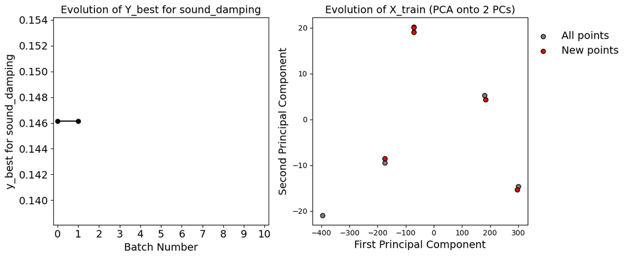

```
Batch 2/10
Job submitted! Check results at: http://abaqus.oit.duke.edu:8000/status/jp630/503
Job submitted! Check results at: http://abaqus.oit.duke.edu:8000/status/jp630/504
Job submitted! Check results at: http://abaqus.oit.duke.edu:8000/status/jp630/505
Job submitted! Check results at: http://abaqus.oit.duke.edu:8000/status/jp630/506
Job submitted! Check results at: http://abaqus.oit.duke.edu:8000/status/jp630/507
```

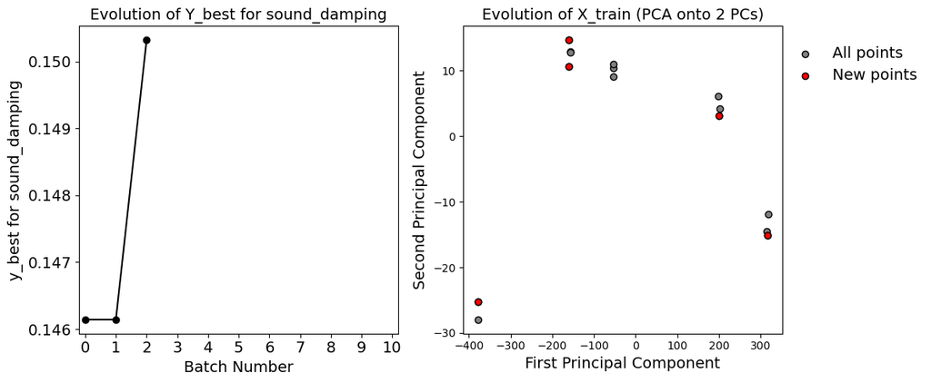

```
Batch 3/10
Job submitted! Check results at: http://abaqus.oit.duke.edu:8000/status/jp630/508
Job submitted! Check results at: http://abaqus.oit.duke.edu:8000/status/jp630/509
Job submitted! Check results at: http://abaqus.oit.duke.edu:8000/status/jp630/510
Job submitted! Check results at: http://abaqus.oit.duke.edu:8000/status/jp630/511
Job submitted! Check results at: http://abaqus.oit.duke.edu:8000/status/jp630/512
```

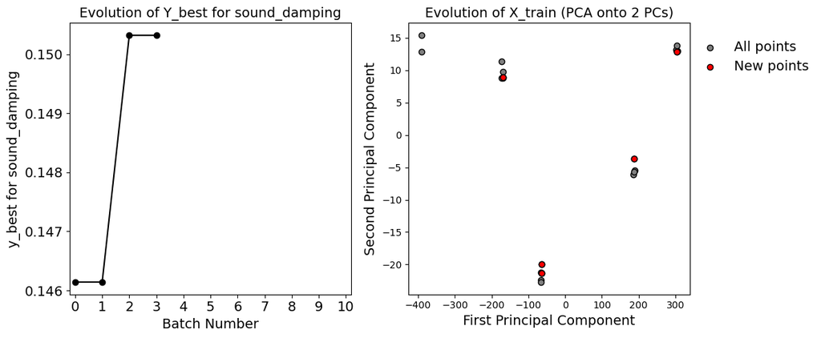

```
Batch 4/10
Job submitted! Check results at: http://abaqus.oit.duke.edu:8000/status/jp630/519
Job submitted! Check results at: http://abaqus.oit.duke.edu:8000/status/jp630/520
Job submitted! Check results at: http://abaqus.oit.duke.edu:8000/status/jp630/521
Job submitted! Check results at: http://abaqus.oit.duke.edu:8000/status/jp630/522
Job submitted! Check results at: http://abaqus.oit.duke.edu:8000/status/jp630/523
```

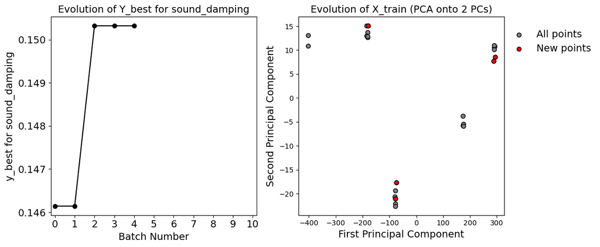

```
Batch 5/10
Job submitted! Check results at: http://abaqus.oit.duke.edu:8000/status/jp630/525
Job submitted! Check results at: http://abaqus.oit.duke.edu:8000/status/jp630/526
Job submitted! Check results at: http://abaqus.oit.duke.edu:8000/status/jp630/527
Job submitted! Check results at: http://abaqus.oit.duke.edu:8000/status/jp630/528
Job submitted! Check results at: http://abaqus.oit.duke.edu:8000/status/jp630/529
```

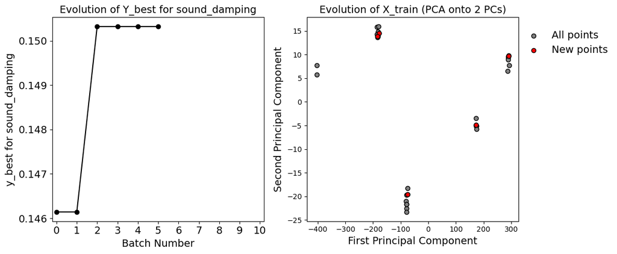

```
Batch 6/10
Job submitted! Check results at: http://abaqus.oit.duke.edu:8000/status/jp630/530
Job submitted! Check results at: http://abaqus.oit.duke.edu:8000/status/jp630/531
Job submitted! Check results at: http://abaqus.oit.duke.edu:8000/status/jp630/532
Job submitted! Check results at: http://abaqus.oit.duke.edu:8000/status/jp630/533
Job submitted! Check results at: http://abaqus.oit.duke.edu:8000/status/jp630/534
```

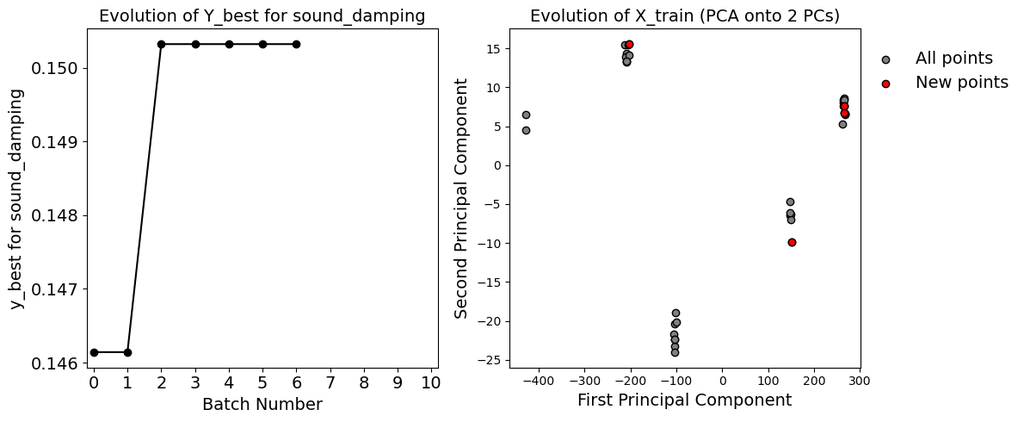

```
Batch 7/10
Job submitted! Check results at: http://abaqus.oit.duke.edu:8000/status/jp630/535
Job submitted! Check results at: http://abaqus.oit.duke.edu:8000/status/jp630/536
Job submitted! Check results at: http://abaqus.oit.duke.edu:8000/status/jp630/537
Job submitted! Check results at: http://abaqus.oit.duke.edu:8000/status/jp630/538
Job submitted! Check results at: http://abaqus.oit.duke.edu:8000/status/jp630/539
```

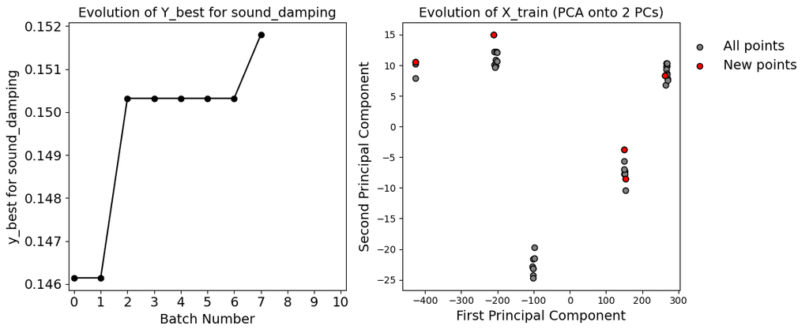

```
Batch 8/10
Job submitted! Check results at: http://abaqus.oit.duke.edu:8000/status/jp630/540
Job submitted! Check results at: http://abaqus.oit.duke.edu:8000/status/jp630/541
Job submitted! Check results at: http://abaqus.oit.duke.edu:8000/status/jp630/542
Job submitted! Check results at: http://abaqus.oit.duke.edu:8000/status/jp630/543
Job submitted! Check results at: http://abaqus.oit.duke.edu:8000/status/jp630/544
```

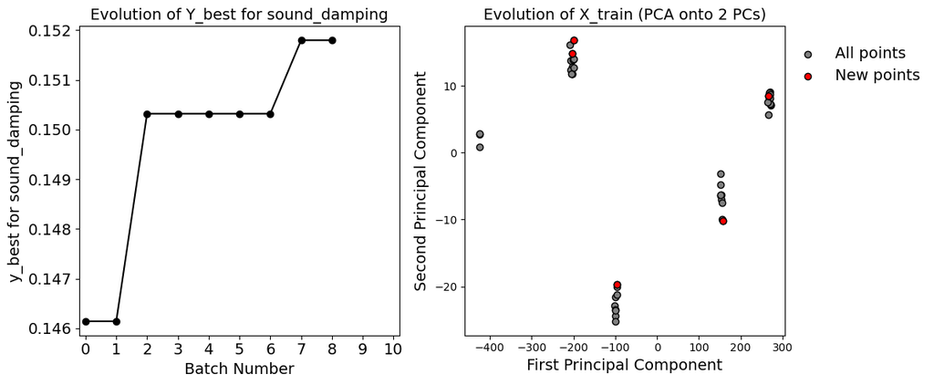

```
Batch 9/10
Job submitted! Check results at: http://abaqus.oit.duke.edu:8000/status/jp630/546
Job submitted! Check results at: http://abaqus.oit.duke.edu:8000/status/jp630/547
Job submitted! Check results at: http://abaqus.oit.duke.edu:8000/status/jp630/548
Job submitted! Check results at: http://abaqus.oit.duke.edu:8000/status/jp630/549
Job submitted! Check results at: http://abaqus.oit.duke.edu:8000/status/jp630/550
```

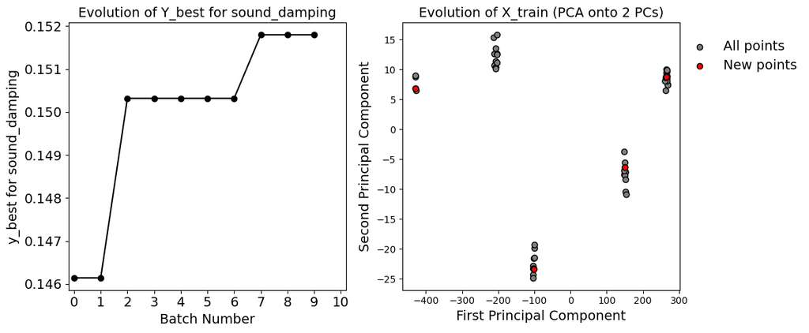

```
Batch 10/10
Job submitted! Check results at: http://abaqus.oit.duke.edu:8000/status/jp630/551
Job submitted! Check results at: http://abaqus.oit.duke.edu:8000/status/jp630/552
Job submitted! Check results at: http://abaqus.oit.duke.edu:8000/status/jp630/553
Job submitted! Check results at: http://abaqus.oit.duke.edu:8000/status/jp630/554
Job submitted! Check results at: http://abaqus.oit.duke.edu:8000/status/jp630/555
```

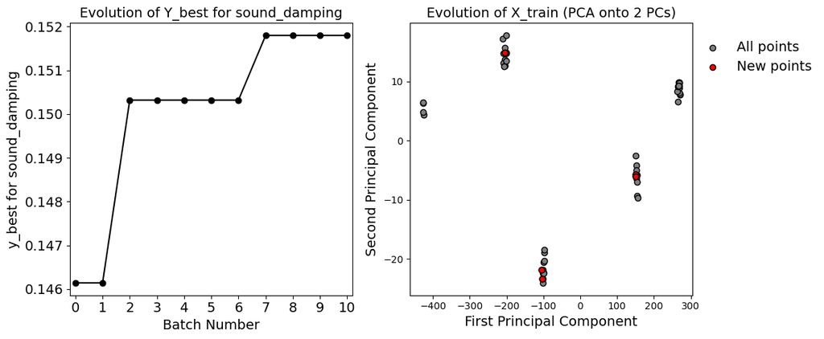

```python
all_urls, y_best_history, X_train = GP_workflow(X_train, y_train, n_batches, batchsize, n_candidate_pts, param_mins, param_maxs, output_list, all_urls, optimization_param, maximization=True)
```

**Notes on the Optimized Process:**

The cumulative best 'sound_damping' response increases throughout the optimization, indicating that the Gaussian Process (GP) is broadly moving in the desired direction. Notably we do not show local fluctuations, that is to say that y_best does not improve from one batch to the next when the y value is steady. The range of improvement appears small (from approximately 0.146 to 0.152), but this slight improvement could have significant physical implications. The X_train data, which is updated throughout the optimization, appears to be rather clustered around the initial points, at least when viewed through the first two principal components (PCs). This clustering might suggest that the process is more exploitative rather than exploratory. However, it's important to note that dimensionality reduction could cause us to lose some information, making it harder to draw definitive conclusions based solely on the visual representation.

The best 'sound_damping' resulting from the simulations ran for 7th batch and its response (and microstructure) can be found at:

http://abaqus.oit.duke.edu:8000/status/jp630/539.

The parameters for which this result was found are:

[v_time, v_temp, x_s, x_cb, mix, grade] = [301, 421, 3, 8, 3, 3]

**Optimization (Minimization) for the Material Cost Response!**

```python
optimization_param = 'material_cost'
maximization=False
```

*Reinitializing Job Specific Inputs*

```python
n_batches = 10
n_candidate_pts = 100000
batchsize = 5
param_mins = [300,  403, 1, 1, 1,  0]
param_maxs = [1000, 453, 10,  35, 11, 100]
output_list = ['material_cost','heating_cost','mixing_cost','sound_damping','rolling_resistance','abrasion','dry_grip','wet_grip']
X_train = np.array(\
            [[520,   450,  7,  4,  4,  54],\
            [874,   435,  9,  33,  8,  76],\
            [991,   410,  5,  22,  9,  96],\
            [627,  451,  2,  14,  11, 29],\
            [301,  422,  4,  7,  1,  3]])
y_best_history = []
```

GP Initialization

```python
all_urls, y_train = GP_initialization(X_train, optimization_param, output_list)
```

```
Job submitted! Check results at: http://abaqus.oit.duke.edu:8000/status/jp630/773
Job submitted! Check results at: http://abaqus.oit.duke.edu:8000/status/jp630/774
Job submitted! Check results at: http://abaqus.oit.duke.edu:8000/status/jp630/775
Job submitted! Check results at: http://abaqus.oit.duke.edu:8000/status/jp630/776
Job submitted! Check results at: http://abaqus.oit.duke.edu:8000/status/jp630/777
```

GP Workflow

```
Batch 1/10
Job submitted! Check results at: http://abaqus.oit.duke.edu:8000/status/jp630/778
Job submitted! Check results at: http://abaqus.oit.duke.edu:8000/status/jp630/779
Job submitted! Check results at: http://abaqus.oit.duke.edu:8000/status/jp630/780
Job submitted! Check results at: http://abaqus.oit.duke.edu:8000/status/jp630/781
Job submitted! Check results at: http://abaqus.oit.duke.edu:8000/status/jp630/782
```

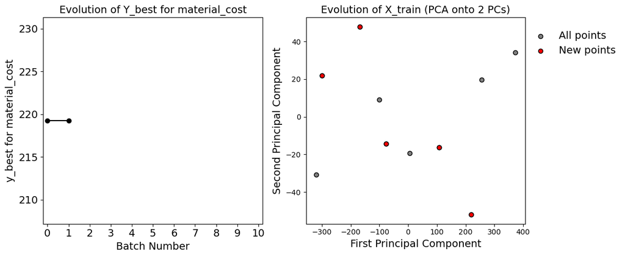

```
Batch 2/10
Job submitted! Check results at: http://abaqus.oit.duke.edu:8000/status/jp630/788
Job submitted! Check results at: http://abaqus.oit.duke.edu:8000/status/jp630/789
Job submitted! Check results at: http://abaqus.oit.duke.edu:8000/status/jp630/790
Job submitted! Check results at: http://abaqus.oit.duke.edu:8000/status/jp630/791
Job submitted! Check results at: http://abaqus.oit.duke.edu:8000/status/jp630/792
```

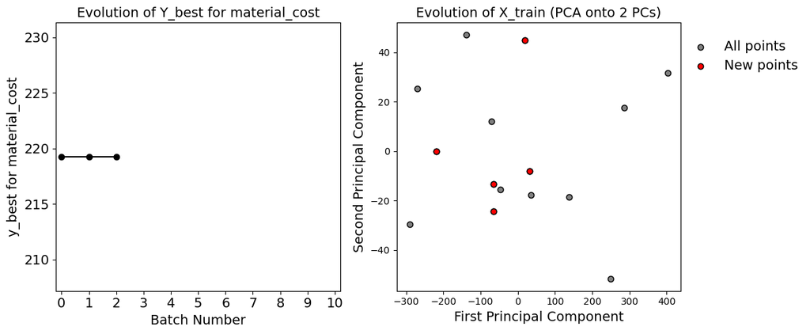

```
Batch 3/10
Job submitted! Check results at: http://abaqus.oit.duke.edu:8000/status/jp630/793
Job submitted! Check results at: http://abaqus.oit.duke.edu:8000/status/jp630/794
Job submitted! Check results at: http://abaqus.oit.duke.edu:8000/status/jp630/795
Job submitted! Check results at: http://abaqus.oit.duke.edu:8000/status/jp630/796
Job submitted! Check results at: http://abaqus.oit.duke.edu:8000/status/jp630/797
```

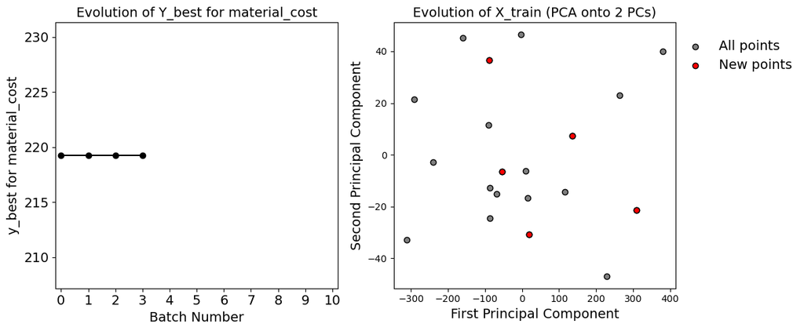

```
Batch 4/10
Job submitted! Check results at: http://abaqus.oit.duke.edu:8000/status/jp630/803
Job submitted! Check results at: http://abaqus.oit.duke.edu:8000/status/jp630/804
Job submitted! Check results at: http://abaqus.oit.duke.edu:8000/status/jp630/805
Job submitted! Check results at: http://abaqus.oit.duke.edu:8000/status/jp630/806
Job submitted! Check results at: http://abaqus.oit.duke.edu:8000/status/jp630/807
```

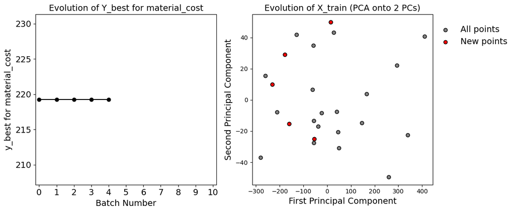

```
Batch 5/10
Job submitted! Check results at: http://abaqus.oit.duke.edu:8000/status/jp630/808
Job submitted! Check results at: http://abaqus.oit.duke.edu:8000/status/jp630/809
Job submitted! Check results at: http://abaqus.oit.duke.edu:8000/status/jp630/810
Job submitted! Check results at: http://abaqus.oit.duke.edu:8000/status/jp630/811
Job submitted! Check results at: http://abaqus.oit.duke.edu:8000/status/jp630/812
```

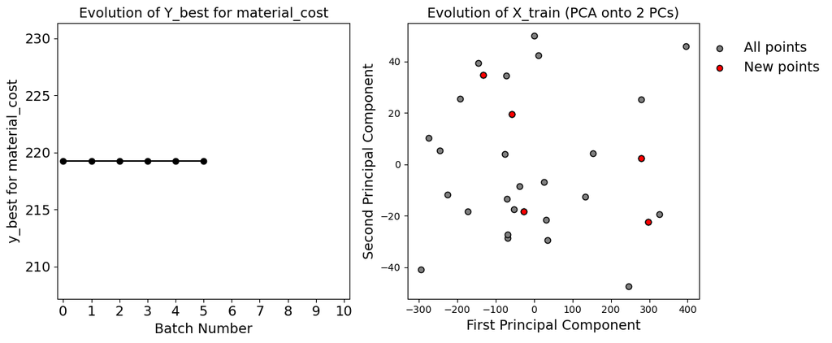

```
Batch 6/10
Job submitted! Check results at: http://abaqus.oit.duke.edu:8000/status/jp630/818
Job submitted! Check results at: http://abaqus.oit.duke.edu:8000/status/jp630/819
Job submitted! Check results at: http://abaqus.oit.duke.edu:8000/status/jp630/820
Job submitted! Check results at: http://abaqus.oit.duke.edu:8000/status/jp630/821
Job submitted! Check results at: http://abaqus.oit.duke.edu:8000/status/jp630/822
```

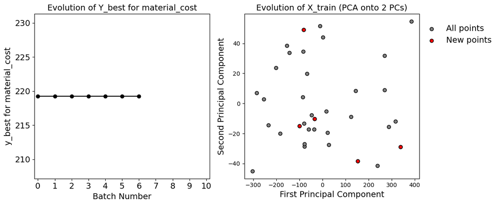

```
Batch 7/10
Job submitted! Check results at: http://abaqus.oit.duke.edu:8000/status/jp630/823
Job submitted! Check results at: http://abaqus.oit.duke.edu:8000/status/jp630/824
Job submitted! Check results at: http://abaqus.oit.duke.edu:8000/status/jp630/825
Job submitted! Check results at: http://abaqus.oit.duke.edu:8000/status/jp630/826
Job submitted! Check results at: http://abaqus.oit.duke.edu:8000/status/jp630/827
```

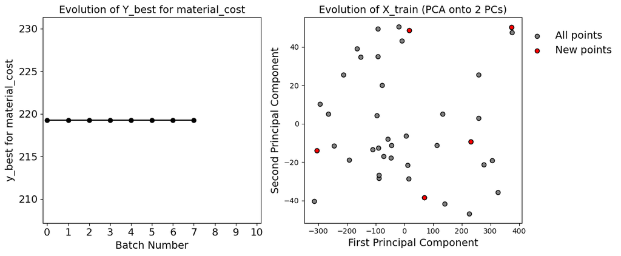

```
Batch 8/10
Job submitted! Check results at: http://abaqus.oit.duke.edu:8000/status/jp630/834
Job submitted! Check results at: http://abaqus.oit.duke.edu:8000/status/jp630/835
Job submitted! Check results at: http://abaqus.oit.duke.edu:8000/status/jp630/836
Job submitted! Check results at: http://abaqus.oit.duke.edu:8000/status/jp630/837
Job submitted! Check results at: http://abaqus.oit.duke.edu:8000/status/jp630/838
```

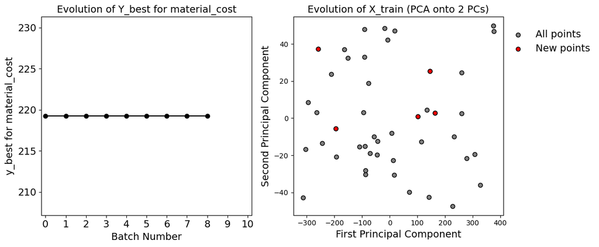

```
Batch 9/10
Job submitted! Check results at: http://abaqus.oit.duke.edu:8000/status/jp630/839
Job submitted! Check results at: http://abaqus.oit.duke.edu:8000/status/jp630/840
Job submitted! Check results at: http://abaqus.oit.duke.edu:8000/status/jp630/841
Job submitted! Check results at: http://abaqus.oit.duke.edu:8000/status/jp630/842
Job submitted! Check results at: http://abaqus.oit.duke.edu:8000/status/jp630/843
```

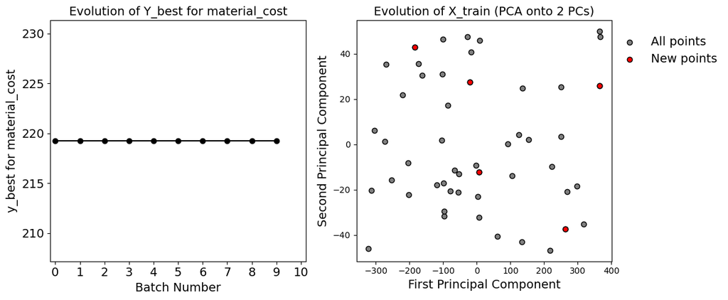

```
Batch 10/10
Job submitted! Check results at: http://abaqus.oit.duke.edu:8000/status/jp630/850
Job submitted! Check results at: http://abaqus.oit.duke.edu:8000/status/jp630/851
Job submitted! Check results at: http://abaqus.oit.duke.edu:8000/status/jp630/852
Job submitted! Check results at: http://abaqus.oit.duke.edu:8000/status/jp630/853
Job submitted! Check results at: http://abaqus.oit.duke.edu:8000/status/jp630/854
```

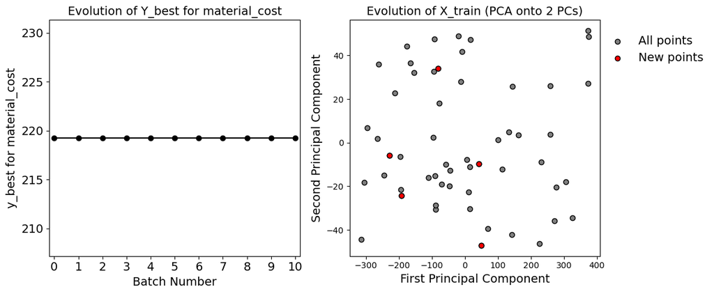

```python
all_urls, y_best_history, X_train = GP_workflow(X_train, y_train, n_batches, batchsize, n_candidate_pts, param_mins, param_maxs, output_list, all_urls, optimization_param, maximization)
```

**Notes on the Optimized Process:**

The best 'material_cost' resulting from the simulations ran for the training set and its response (and microstructure) can be found at:

http://abaqus.oit.duke.edu:8000/status/jp630/777

The parameters for which this result was found are:

[v_time, v_temp, x_s, x_cb, mix, grade] = [301, 422, 4, 7, 1, 3]